# Homework 3 Models

Wolfgang Brightenburg

10/3/2021

# Code Chunks for Each Model

```r
Full_Model_processing <- function(my_data){
  my_data
}

Full_Model_model <- function(training_data){
  library(tidyverse)     ## Load whatever packages you need
  my_mod <- lm(Sale_Price ~ .,
               data = training_data)
  my_mod
}

Full_Model_predictions <- function(model, test_data){
  library(tidyverse)     ## Load whatever packages you need
  my_preds <- predict(model, test_data)   ## Make predictions based on your model. Don't change this line.
  my_preds<- my_preds*1
  my_preds
}
```

```r
Simple_Model_processing <- function(my_data){
  my_data
}

Simple_Model_model <- function(training_data){
  library(tidyverse)     ## Load whatever packages you need
  my_mod <- lm(Sale_Price ~ Gr_Liv_Area,
               data = training_data)
  my_mod
}

Simple_Model_predictions <- function(model, test_data){
  library(tidyverse)     ## Load whatever packages you need
  my_preds <- predict(model, test_data)   ## Make predictions based on your model. Don't change this line.
  my_preds<- my_preds*1
  my_preds
}
```

```r
Ananke_Krishnan_processing <- function(my_data){
  my_data
}

Ananke_Krishnan_model <- function(training_data){
  library(tidyverse)     ## Load whatever packages you need
  my_mod <- lm(Sale_Price ~ Year_Built + First_Flr_SF + TotRms_AbvGrd + Garage_Area + House_Style +
                 Overall_Cond + First_Flr_SF*Garage_Area,
               data = training_data)
  my_mod
}

Ananke_Krishnan_predictions <- function(model, test_data){
  library(tidyverse)     ## Load whatever packages you need
  my_preds <- predict(model, test_data)   ## Make predictions based on your model. Don't change this line.
  my_preds<- my_preds*1
  my_preds
}
```

```r
Bhavjot_Khurana_processing <- function(my_data){
  processed_data <- my_data #%>% filter(Lot_Area < 40000)
  processed_data
}

Bhavjot_Khurana_model <- function(training_data){
  library(tidyverse)     ## Load whatever packages you need
  my_mod <- lm(Sale_Price ~ Exter_Cond + poly(Lot_Area, degree = 2) + Garage_Area + TotRms_AbvGrd + Year_Remod_Add + Year_Built + Year_Built:Year_Remod_Add, data = training_data)
  my_mod
}

Bhavjot_Khurana_predictions <- function(model, test_data){
  library(tidyverse)     ## Load whatever packages you need
  my_preds <- predict(model, test_data)   ## Make predictions based on your model. Don't change this line.
  my_preds<- my_preds*1
}
```

```r
Calvin_BeemanWeber_processing <- function(my_data){
  library(tidyverse) ## Load whatever packages you need
  processed_data <- my_data %>% mutate(Sale_Price = Sale_Price) ## Include all relevant processing steps. The included step is just a placeholder example
  processed_data
}

Calvin_BeemanWeber_model <- function(training_data){
  library(tidyverse)     ## Load whatever packages you need
  my_mod <- lm(log(Sale_Price) ~ MS_Zoning + Year_Built + Overall_Cond + Year_Built + Gr_Liv_Area + Year_Remod_Add + Full_Bath + Year_Built:Year_Remod_Add, data = training_data)    ## Create your model. Replace 1 with your actual model formula. Do not replace "training_data"
  my_mod      ##return your model as output
}

Calvin_BeemanWeber_predictions <- function(model, test_data){
  library(tidyverse)     ## Load whatever packages you need
  my_preds <- predict(model, test_data)   ## Make predictions based on your model. Don't change this line.
  my_preds<- exp(my_preds) ## Transform your model predictions back to the original units for Sale_Price, if necessary
  my_preds      ##return your predictions as output
}
```

```r
Emma_Thoron_processing <- function(my_data){
  library(tidyverse) ## Load whatever packages you need
  processed_data <- my_data %>% mutate(Gr_Liv_Area = sqrt(Gr_Liv_Area)) ## Include all relevant processing steps. The included step is just a placeholder example
  processed_data ## returns the processed data as output
}

Emma_Thoron_model <- function(training_data){
  library(tidyverse)     ## Load whatever packages you need
  my_mod <- lm(log(Sale_Price) ~ sqrt(Gr_Liv_Area) +
              Total_Bsmt_SF +
              Garage_Area +
              Paved_Drive +
              Central_Air +
              Heating_QC, data = training_data)    ## Create your model. Replace 1 with your actual model formula. Do not replace "training_data"
  my_mod      ##return your model as output
}

Emma_Thoron_predictions <- function(model, test_data){
  library(tidyverse)     ## Load whatever packages you need
  my_preds <- predict(model, test_data)   ## Make predictions based on your model. Don't change this line.
  my_preds<- exp(my_preds) ## Transform your model predictions back to the original units for Sale_Price, if necessary
  my_preds      ##return your predictions as output
}
```

```r
Gillian_McGinnis_processing <- function(my_data){
  # library(tidyverse)
  processed_data <- my_data
  processed_data
}

Gillian_McGinnis_model <- function(training_data){
  my_mod <- lm(
    log(Sale_Price) ~
      poly(Year_Built, degree=2, raw = TRUE) +
      Gr_Liv_Area + Lot_Area + TotRms_AbvGrd + Total_Bsmt_SF + Garage_Area + Fireplaces +
      Overall_Cond +
      Year_Built:House_Style,
    data = training_data)    # creating model
  my_mod      # returns model as output
}

Gillian_McGinnis_predictions <- function(model, test_data){
  my_preds <- predict(model, test_data)   # making predictions based on model
  my_preds <- exp(my_preds) # xform model predictions back to the original units for Sale_Price
  my_preds      # return predictions as output
}
```

```r
Isabelle_Caldwell_processing <- function(my_data){
  library(tidyverse) ## Load whatever packages you need
  processed_data <- my_data %>% mutate(BsmtFin_Type_1 = fct_relevel(BsmtFin_Type_1, "No_Basement", "Unf", "LwQ", "Rec", "BLQ", "ALQ", "GLQ"),
                                       Overall_Cond = fct_relevel(Overall_Cond, "Very_Poor", "Poor", "Fair", "Below_Average", "Average", "Above_Average", "Good", "Very_Good", "Excellent"))
  processed_data ## returns the processed data as output
}

Isabelle_Caldwell_model <- function(training_data){
  library(tidyverse)     ## Load whatever packages you need
  my_mod <- lm(Sale_Price ~ Year_Built + BsmtFin_Type_1  + Fireplaces  + Garage_Area + House_Style  + Gr_Liv_Area + I(Gr_Liv_Area^2), data = training_data)    ## Create your model. Replace 1 with your actual model formula. Do not replace "training_data"
  my_mod      ##return your model as output
}

Isabelle_Caldwell_predictions <- function(model, test_data){
  library(tidyverse)     ## Load whatever packages you need
  my_preds <- predict(model, test_data)   ## Make predictions based on your model. Don't change this line.
  my_preds<- my_preds*1 ## Transform your model predictions back to the original units for Sale_Price, if necessary
  my_preds      ##return your predictions as output
}
```

```r
Jakob_Shimer_processing <- function(my_data){
  return(my_data)
}

Jakob_Shimer_model <- function(training_data){
  my_mod <- lm(log(Sale_Price) ~ Garage_Area + poly(Year_Built, 2) + Gr_Liv_Area + First_Flr_SF*Electrical + TotRms_AbvGrd + Overall_Cond + Heating_QC + Functional ,data = training_data)
  my_mod      ##return your model as output
}

Jakob_Shimer_predictions <- function(model, test_data){
     ##return your predictions as output
  my_preds <- predict(model, test_data)
  exp(my_preds)      ##return your predictions as output
}
```

```r
Jon_deVries_processing <- function(my_data){
  library(tidyverse) ## Load whatever packages you need
  processed_data <- my_data  ## Include all relevant processing steps. The included step is just a placeholder example
  processed_data ## returns the processed data as output
}

Jon_deVries_model <- function(training_data){
  library(tidyverse)     ## Load whatever packages you need
  my_mod <- lm(Sale_Price ~ Lot_Area + Gr_Liv_Area + Year_Remod_Add + Sale_Type + Overall_Cond + Condition_1, data = training_data)    ## Create your model. Replace 1 with your actual model formula. Do not replace "training_data"
  my_mod      ##return your model as output
}

Jon_deVries_predictions <- function(model, test_data){
  library(tidyverse)     ## Load whatever packages you need
  my_preds <- predict(model, test_data)   ## Make predictions based on your model. Don't change this line.
  my_preds<- my_preds*1 ## Transform your model predictions back to the original units for Sale_Price, if necessary
  my_preds      ##return your predictions as output
}
```

```r
Kenai_BurtonHeckman_processing <- function(my_data){
  library(tidyverse) ## Load whatever packages you need
  library(fastDummies)
  processed_data <- my_data %>% ## Include all relevant processing steps. The included step is just a placeholder example
    dummy_cols(remove_first_dummy = T) %>%
    select(where(is.numeric)) %>%
    rename_with(~ gsub(" ", "", .x, fixed = TRUE))
  processed_data ## returns the processed data as output
}

Kenai_BurtonHeckman_model <- function(training_data){
  library(tidyverse)     ## Load whatever packages you need
  #forgive me
  my_mod <- lm(Sale_Price ~ Lot_Frontage + Lot_Area + Year_Built + Year_Remod_Add +
    Mas_Vnr_Area + BsmtFin_SF_1 + Bsmt_Unf_SF + Total_Bsmt_SF +
    First_Flr_SF + Second_Flr_SF + Gr_Liv_Area + Bsmt_Full_Bath +
    Bedroom_AbvGr + Kitchen_AbvGr + Fireplaces + Garage_Cars +
    Garage_Area + Wood_Deck_SF + Screen_Porch + Pool_Area + Latitude +
    MS_SubClass_One_and_Half_Story_Finished_All_Ages + MS_SubClass_One_and_Half_Story_Unfinished_All_Ages +
    MS_SubClass_One_Story_1945_and_Older + MS_SubClass_One_Story_1946_and_Newer_All_Styles +
    MS_SubClass_One_Story_with_Finished_Attic_All_Ages + MS_SubClass_PUD_Multilevel_Split_Level_Foyer +
    MS_SubClass_Two_Family_conversion_All_Styles_and_Ages + MS_SubClass_Two_Story_1945_and_Older +
    MS_SubClass_Two_Story_PUD_1946_and_Newer + MS_Zoning_Floating_Village_Residential +
    MS_Zoning_Residential_Low_Density + Alley_No_Alley_Access +
    Lot_Shape_Moderately_Irregular + Lot_Shape_Regular + Lot_Shape_Slightly_Irregular +
    Land_Contour_HLS + Lot_Config_CulDSac + Lot_Config_Inside +
    Land_Slope_Sev + Condition_1_Norm + Condition_1_PosA + Condition_1_PosN +
    Bldg_Type_OneFam + Bldg_Type_Twnhs + Bldg_Type_TwnhsE + House_Style_One_Story +
    House_Style_SFoyer + House_Style_SLvl + House_Style_Two_and_Half_Fin +
    House_Style_Two_and_Half_Unf + House_Style_Two_Story + Overall_Cond_Average +
    Overall_Cond_Below_Average + Overall_Cond_Excellent + Overall_Cond_Fair +
    Overall_Cond_Good + Overall_Cond_Poor + Overall_Cond_Very_Good +
    Overall_Cond_Very_Poor + Roof_Style_Gable + Roof_Style_Gambrel +
    Roof_Style_Mansard + Exterior_1st_CemntBd + Exterior_1st_HdBoard +
    Exterior_1st_Stucco + Exterior_1st_VinylSd + Exterior_1st_WdSdng +
    Exterior_2nd_BrkFace + Exterior_2nd_Plywood + Exterior_2nd_WdSdng +
    Exterior_2nd_WdShng + Mas_Vnr_Type_BrkFace + Mas_Vnr_Type_Stone +
    Exter_Cond_Fair + Foundation_PConc + Foundation_Stone + Bsmt_Cond_Poor +
    Bsmt_Exposure_Mn + Bsmt_Exposure_No + Bsmt_Exposure_No_Basement +
    BsmtFin_Type_1_LwQ + BsmtFin_Type_1_Rec + BsmtFin_Type_2_GLQ +
    BsmtFin_Type_2_No_Basement + BsmtFin_Type_2_Rec + BsmtFin_Type_2_Unf +
    Heating_QC_Good + Electrical_FuseP + Functional_Typ + Garage_Type_Basment +
    Garage_Type_CarPort + Garage_Type_More_Than_Two_Types + Garage_Finish_RFn +
    Garage_Cond_Poor + Paved_Drive_Partial_Pavement + Paved_Drive_Paved +
    Fence_Minimum_Privacy + Fence_Minimum_Wood_Wire + Bldg_Type_TwoFmCon, data = training_data)    ## Create your model. Replace 1 with your actual model formula. Do not replace "training_data"
  my_mod      ##return your model as output
}

Kenai_BurtonHeckman_predictions <- function(model, test_data){
  library(tidyverse)     ## Load whatever packages you need
  my_preds <- predict(model, test_data)   ## Make predictions based on your model. Don't change this line.
  my_preds      ##return your predictions as output
}
```

```r
Maxwell_VanLandschoot_processing <- function(my_data){
  library(tidyverse)
  library(rsample) #just in case
  library(gglm) #just in case
  library(lmtest) #just in case
  processed_data <- my_data %>%
    mutate(log_Sale_Price = log(Sale_Price)) %>%
    mutate(Overall_Cond = case_when(Overall_Cond == "Very_Poor"~ "Below_Average",
                                  Overall_Cond =="Poor" ~ "Below_Average",
                                  Overall_Cond =="Fair" ~ "Below_Average",
                                  Overall_Cond =="Above_Average" ~ "Above_Average",
                                  Overall_Cond =="Excellent" ~ "Above_Average",
                                  Overall_Cond =="Good" ~ "Above_Average",
                                  Overall_Cond =="Average" ~ "Average",
                                  Overall_Cond =="Very_Good" ~ "Above_Average",
                                  Overall_Cond =="Below_Average" ~ "Below_Average"
                                  )) %>%
        mutate(MS_SubClass = case_when(MS_SubClass =="One_and_Half_Story_PUD_All_Ages"~ "Other",
                                   MS_SubClass =="One_Story_with_Finished_Attic_All_Ages"~ "Other",
                                   MS_SubClass =="PUD_Multilevel_Split_Level_Foyer"~ "Other",
                                   MS_SubClass =="One_and_Half_Story_Unfinished_All_Ages"~ "Other",
                                   MS_SubClass =="Two_and_Half_Story_All_Ages"~ "Other",
                                   TRUE ~ as.character(MS_SubClass)
                                   )) %>%
    mutate(Garage_Cars = case_when(Garage_Cars == 5 ~ "3+",
                                   Garage_Cars == 4 ~ "3+",
                                   Garage_Cars == 3 ~ "3+",
                                   Garage_Cars == 2 ~ "2",
                                   Garage_Cars == 1 ~ "1",
                                   Garage_Cars == 0 ~ "0",
                                   ))
  processed_data
}

Maxwell_VanLandschoot_model <- function(training_data){
  library(tidyverse)
  my_mod <- lm(log_Sale_Price ~ log(Lot_Area) + Total_Bsmt_SF +
                 Gr_Liv_Area +
                 Overall_Cond +
                 MS_SubClass +
                 Bsmt_Exposure +
                 Fireplaces +
                 as.character(Garage_Cars) +
                 Year_Built +
                 Year_Remod_Add, data = training_data)
  my_mod
}

Maxwell_VanLandschoot_predictions <- function(model, test_data){    ## Load whatever packages you need
  my_preds <- predict(model, test_data)   ## Make predictions based on your model. Don't change this line.
  my_preds <- exp(my_preds) ## Transform your model predictions back to the original units for Sale_Price, if necessary
  my_preds ##return your predictions as output
}
```

```r
Rishi_Krishnamurthy_processing <- function(my_data){
  my_data$Overall_Cond <- as.factor(my_data$Overall_Cond)
  my_data$Overall_Cond <- my_data$Overall_Cond %>% fct_relevel("Very_Poor",
                                                         "Poor",
                                                         "Below_Average",
                                                         "Average",
                                                         "Above_Average",
                                                         "Fair",
                                                         "Good",
                                                         "Very_Good",
                                                         "Excellent")
  my_data <- my_data %>% mutate(log_price = log(Sale_Price))
  processed_data <- my_data
  ## Include all relevant processing steps. The included step is just a placeholder example
  processed_data ## returns the processed data as output
}

Rishi_Krishnamurthy_model <- function(training_data){
  my_mod <- lm(log_price ~ Overall_Cond*Gr_Liv_Area+Lot_Area+Year_Built+Year_Remod_Add+Heating_QC+MS_SubClass+House_Style+Garage_Area, data = training_data)    ## Create your model. Replace 1 with your actual model formula. Do not replace "training_data"
  my_mod      ##return your model as output
}

Rishi_Krishnamurthy_predictions <- function(model, test_data){
  my_preds <- predict(model, test_data)
  my_preds<- exp(my_preds)
  my_preds
}
```

```r
Robin_H_processing <- function(my_data){
  my_data
}

Robin_H_model <- function(training_data){
  my_mod <- lm(Sale_Price ~ MS_Zoning + Lot_Frontage + Lot_Area + Street + Alley + Lot_Shape
               + Land_Contour + Lot_Config + Land_Slope + Bldg_Type + House_Style + Year_Built
               + Year_Remod_Add + Roof_Style + Mas_Vnr_Type + Mas_Vnr_Area + Exter_Cond
               + Foundation + Bsmt_Exposure + BsmtFin_Type_1 + BsmtFin_SF_1 + BsmtFin_Type_2
               + BsmtFin_SF_2 + Bsmt_Unf_SF + Total_Bsmt_SF + Heating_QC + Central_Air
               + Electrical + First_Flr_SF + Second_Flr_SF + Gr_Liv_Area + Bsmt_Full_Bath
               + Bsmt_Half_Bath + Bedroom_AbvGr + Kitchen_AbvGr + Functional + Fireplaces
               + Garage_Type + Garage_Finish + Garage_Cars + Garage_Area + Garage_Cond
               + Paved_Drive + Wood_Deck_SF + Open_Porch_SF + Enclosed_Porch
               + Three_season_porch + Screen_Porch + Pool_Area + Fence + Misc_Val + Mo_Sold
               + Year_Sold + Sale_Price + Longitude + Latitude, data = training_data)    ## Create your model. Replace 1 with your actual model formula. Do not replace "training_data"
  my_mod      ##return your model as output
}

Robin_H_predictions <- function(model, test_data){
  library(tidyverse)     ## Load whatever packages you need
  my_preds <- predict(model, test_data)   ## Make predictions based on your model. Don't change this line.
  my_preds<- my_preds*1 ## Transform your model predictions back to the original units for Sale_Price, if necessary
  my_preds      ##return your predictions as output
}
```

```r
Rohan_Buggana_processing <- function(house){

  processed_data <- house %>% mutate(Sale_Price = log10(Sale_Price)) ## Include all relevant processing steps. The included step is just a placeholder example
  processed_data ## returns the processed data as output
}

Rohan_Buggana_model <- function(training_data){
  my_mod <- lm(Sale_Price ~ Gr_Liv_Area + First_Flr_SF + Year_Built + Garage_Cars + Bldg_Type + Exter_Cond, data = training_data)    ## Create your model. Replace 1 with your actual model formula. Do not replace "training_data"
  my_mod      ##return your model as output
}

Rohan_Buggana_predictions <- function(model, test_data){   ## Load whatever packages you need
  my_preds <- predict(model, test_data)   ## Make predictions based on your model. Don't change this line.
  my_preds <- 10^(my_preds) ## Transform your model predictions back to the original units for Sale_Price, if necessary
  my_preds      ##return your predictions as output
}
```

```r
simon_ahn_processing <- function(my_data){
  my_data ## returns the processed data as output
}

simon_ahn_model <- function(training_data){
  my_mod <- lm(log(Sale_Price) ~ Overall_Cond + Fireplaces + MS_Zoning + Garage_Area +Full_Bath + Total_Bsmt_SF   , data = training_data)## Create your model. Replace 1 with your actual model formula. Do not replace "training_data"
  my_mod
}

simon_ahn_predictions <- function(model, test_data){    ## Load whatever packages you need
  my_preds <- predict(model, test_data)   ## Make predictions based on your model. Don't change this line.
  my_preds<- exp(my_preds)## Transform your model predictions back to the original units for Sale_Price, if necessary
  my_preds      ##return your predictions as output
}
```

```r
SkyPeterson_processing <- function(Data){
  DataProcessed <- Data %>%
    mutate(LogSale = log10(Sale_Price)) %>%
    select(-Sale_Price)
  DataProcessed ## returns the processed data as output
}

SkyPeterson_model <- function(DataTraining){
  Mod <- lm(LogSale ~ Overall_Cond + Gr_Liv_Area + Total_Bsmt_SF + Fireplaces + Garage_Cars + MS_Zoning + Year_Built + Bedroom_AbvGr, data = DataTraining)    ## Create your model. Replace 1 with your actual model formula. Do not replace "training_data"
  Mod      ##return your model as output
}

SkyPeterson_predictions <- function(Model, DataTest){
  Preds <- predict(Model, DataTest)   ## Make predictions based on your model. Don't change this line.
  Preds<- 10^Preds ## Transform your model predictions back to the original units for Sale_Price, if necessary
  Preds      ##return your predictions as output
}
```

```r
Taylor_Blair_processing <- function(my_data){
  center_of_ames <- c(mean(my_data$Latitude), mean(my_data$Longitude))
  processed_data <- my_data %>%
    mutate_if(is.character,as.factor) %>%
    mutate(dist_from_center_lat = (center_of_ames[1]-Latitude)*364000,
         dist_from_center_long = (center_of_ames[2]-Longitude)*288200,
         dist_from_center = sqrt((dist_from_center_lat^2)+ (dist_from_center_long^2))) ## Include all relevant processing steps. The included step is just a placeholder example
  processed_data ## returns the processed data as output
}

Taylor_Blair_model <- function(training_data){
  my_mod <- lm(Sale_Price ~ . + Screen_Porch:Lot_Area, data = training_data)    ## Create your model. Replace 1 with your actual model formula. Do not replace "training_data"
  my_mod      ##return your model as output
}

Taylor_Blair_predictions <- function(model, test_data){
  library(tidyverse)     ## Load whatever packages you need
  my_preds <- predict(model, test_data)   ## Make predictions based on your model. Don't change this line.
  my_preds<- my_preds*1
}
```

```r
Tina_Qin_processing <- function(my_data){
  library(tidyverse) ## Load whatever packages you need
  processed_data <- my_data %>% mutate(Sale_Price = Sale_Price) ## Include all relevant processing steps. The included step is just a placeholder example
  processed_data ## returns the processed data as output
}

Tina_Qin_model <- function(training_data){
  library(tidyverse)     ## Load whatever packages you need
  my_mod <- lm(Sale_Price ~ Overall_Cond + Heating_QC + Central_Air + Bsmt_Cond + I((Lot_Area)^2) + Gr_Liv_Area + TotRms_AbvGrd + TotRms_AbvGrd*Gr_Liv_Area, data = training_data)    ## Create your model. Replace 1 with your actual model formula. Do not replace "training_data"
  my_mod      ##return your model as output
}

Tina_Qin_predictions <- function(model, test_data){
  library(tidyverse)     ## Load whatever packages you need
  my_preds <- predict(model, test_data)   ## Make predictions based on your model. Don't change this line.
  my_preds<- my_preds*1 ## Transform your model predictions back to the original units for Sale_Price, if necessary
  my_preds      ##return your predictions as output
}
```

# Model Evaluation

Please note that the Kenai_BurtonHeckman functions did not work with the construct results function, and need to be evaluated manually. I think this is because of some strangeness in processing the test data with the fastDummies library which Kenai used; my theory is that when the test data’s categorical variables are split apart into one hot variables, some factors that have one-hot variables in the training data aren’t present in the test data so the model is trying to predict on data that’s missing one or more variables.

A few models were slightly adjusted to allow function to run on test data:

1. Bhav had a pre-processing step that filtered out observations with lot area greater than 40000, which was dropping one of the test observations, and meant that his prediction vector was shorter than others.
2. Calvin interpreted `log` as base 10, rather than base `e`, resulting in prediction errors that were not on the same scale as others.
3. I was able to add Kenai’s model by combining test and training sets before performing hot-one encoding, then splitting them again. I did need to run a seperate function from `construct_results` to do so.

```r
library(tidyverse)
training_data <- read_csv("house_train.csv")
#Vector of student names to iterate over
names <- c("Ananke_Krishnan",
           "Bhavjot_Khurana",
           "Calvin_BeemanWeber",
           "Emma_Thoron",
           "Gillian_McGinnis",
           "Isabelle_Caldwell",
           "Jakob_Shimer",
           "Jon_deVries",
           "Rishi_Krishnamurthy",
           "Robin_H",
           "Rohan_Buggana",
           "simon_ahn",
           "SkyPeterson",
           "Tina_Qin",
           "Maxwell_VanLandschoot",
            "Taylor_Blair",
           "Full_Model",
           "Simple_Model"
           )

#Call the processing data function, model construction function, and predictions function associated with a given name,
#model built on input training data, model tested on input test data
evaluate_model <- function(name, training_data, test_data){
  processed_training_data <- do.call(paste(name, "processing", sep = "_"),
                            list(training_data))

  processed_test_data <- do.call(paste(name, "processing", sep = "_"),
                            list(test_data))

  mod <- do.call(paste(name, "model", sep = "_"),
                 list(processed_training_data))
  predictions <- do.call(paste(name, "predictions", sep = "_"),
          list(mod, processed_test_data))
  return(predictions)
}

#called evaluate model function on each name, builds data frame of predictions for each student's model
#column of df is a student's model, rows are individual predictions
construct_results <- function(training_data, test_data){
  results <- sapply(names, function(x){evaluate_model(x,
                         training_data,
                         test_data) }) %>% as.data.frame()
}

#Test of construct_results function
results_example <- construct_results(training_data,
                                     sample_n(training_data, size = 200))
house_test <- read_csv("house_test.csv")
results <- construct_results(training_data,
                                    house_test)
kenai_data <- rbind(training_data %>% mutate(split = "train"), house_test %>% mutate(split = "test")) %>% Kenai_BurtonHeckman_processing()
kenai_process_train <- kenai_data %>% filter(split_train ==1)
kenai_process_test <- kenai_data %>% filter(split_train ==0)
kenai_mod <- Kenai_BurtonHeckman_model(kenai_process_train)
```

```r
results <- cbind(results,
                 Kenai_BurtonHeckman = predict(kenai_mod, kenai_process_test)
                 )
```

```r
get_rmse <- function(preds){
  sqrt(
    mean(
      (preds - house_test$Sale_Price)^2
    )
  )
}
```

```r
results %>%
  summarize(
  across(.cols = everything(), get_rmse)
)
```

```
##   Ananke_Krishnan Bhavjot_Khurana Calvin_BeemanWeber Emma_Thoron
## 1        34862.88        43859.85           37455.93    32647.68
##   Gillian_McGinnis Isabelle_Caldwell Jakob_Shimer Jon_deVries
## 1         26326.03          34040.33     30337.28    43577.88
##   Rishi_Krishnamurthy  Robin_H Rohan_Buggana simon_ahn SkyPeterson Tina_Qin
## 1            33788.33 24063.12      31041.17  35611.34    26364.56  45219.5
##   Maxwell_VanLandschoot Taylor_Blair Full_Model Simple_Model
## 1              23760.69     23417.42   23732.87     51035.41
##   Kenai_BurtonHeckman
## 1            24575.69
```

```r
rMSE <- data.frame()
for(i in 1:20){
  boot <- house_test %>% sample_n(size=597, replace = T)
  results <- construct_results(training_data,
                                    boot)
kenai_data <- rbind(training_data %>% mutate(split = "train"), boot %>% mutate(split = "test")) %>% Kenai_BurtonHeckman_processing()
kenai_process_train <- kenai_data %>% filter(split_train ==1)
kenai_process_test <- kenai_data %>% filter(split_train ==0)
kenai_mod <- Kenai_BurtonHeckman_model(kenai_process_train)
results <- cbind(results,
                 Kenai_BurtonHeckman = predict(kenai_mod, kenai_process_test)
                 )
  get_rmse <- function(preds){
  sqrt(
    mean(
      (preds - boot$Sale_Price)^2
    )
  )
  }
  rMSE <- rbind(rMSE, results %>%
  summarize(
  across(.cols = everything(), get_rmse)
))
}
```

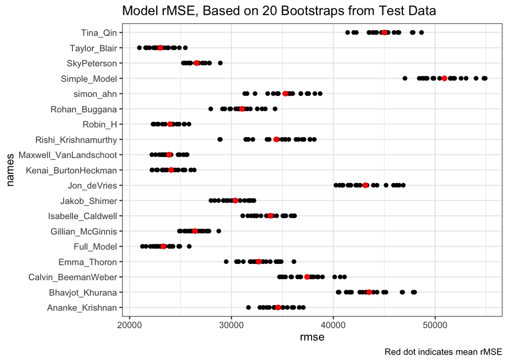

```r
rMSE %>%
  mutate(bootstrap = as.factor(1:20)) %>%
  pivot_longer(!bootstrap, names_to = "names", values_to = "rmse") %>%
  ggplot(aes(x = names, y = rmse)) +
  geom_point()+
  stat_summary(fun = "mean", geom = "point", color = "red", size = 2)+
  coord_flip()+labs(title = "Model rMSE, Based on 20 Bootstraps from Test Data",
                    caption = "Red dot indicates mean rMSE")+
  theme_bw()
```

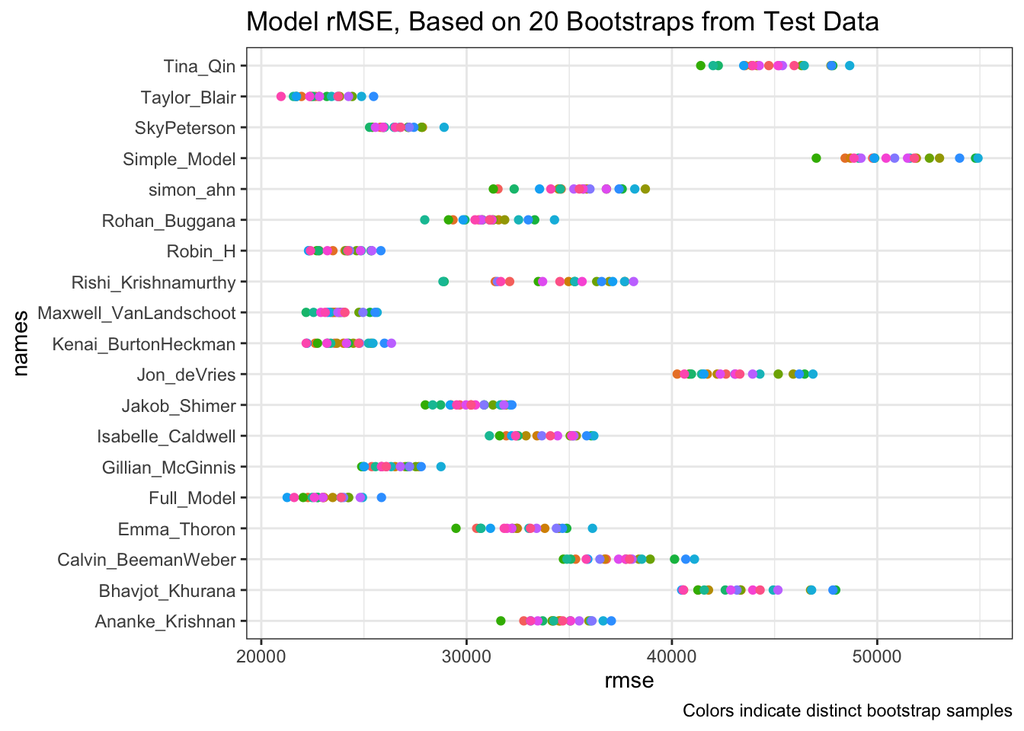

```r
rMSE %>% mutate(bootstrap = as.factor(1:20)) %>% pivot_longer(!bootstrap, names_to = "names", values_to = "rmse") %>% ggplot(aes(x = names, y = rmse, color = bootstrap)) +
  geom_point()+
  coord_flip()+
  labs(title = "Model rMSE, Based on 20 Bootstraps from Test Data",
       caption = "Colors indicate distinct bootstrap samples")+
  theme_bw()+
  theme(legend.position = "none")
```

```r
rMSE %>%
mutate(bootstrap = as.factor(1:20)) %>%
pivot_longer(!bootstrap, names_to = "names", values_to = "rmse") %>% group_by(names) %>% summarize(mean_rmse = mean(rmse), sd_rmse= sd(rmse)) %>% arrange(desc(mean_rmse))
```

```
## # A tibble: 19 x 3
##    names                 mean_rmse sd_rmse
##    <chr>                     <dbl>   <dbl>
##  1 Simple_Model             50908.   2182.
##  2 Tina_Qin                 45008.   2040.
##  3 Bhavjot_Khurana          43525.   2411.
##  4 Jon_deVries              43143.   2078.
##  5 Calvin_BeemanWeber       37419.   1880.
##  6 simon_ahn                35294.   2060.
##  7 Ananke_Krishnan          34580.   1385.
##  8 Rishi_Krishnamurthy      34389.   2847.
##  9 Isabelle_Caldwell        33833.   1619.
## 10 Emma_Thoron              32678.   1716.
## 11 Rohan_Buggana            31035.   1495.
## 12 Jakob_Shimer             30396.   1301.
## 13 SkyPeterson              26589.    950.
## 14 Gillian_McGinnis         26415.   1053.
## 15 Kenai_BurtonHeckman      24080.   1214.
## 16 Robin_H                  23964.   1137.
## 17 Maxwell_VanLandschoot    23877.    950.
## 18 Full_Model               23306.   1174.
## 19 Taylor_Blair             23019.   1193.
```